# Badanie zbieżności rozkładu średniej arytmetycznej

Jakub Wasiczek, Dawid Serek, Dawid Żakieta

2024-01-04

# Wariant I

## Teoretyczny rozkład $\chi^{2}$ (ad. 0)

Rozkłady $\chi^{2}$ o 2 i 40 stopniach swobody

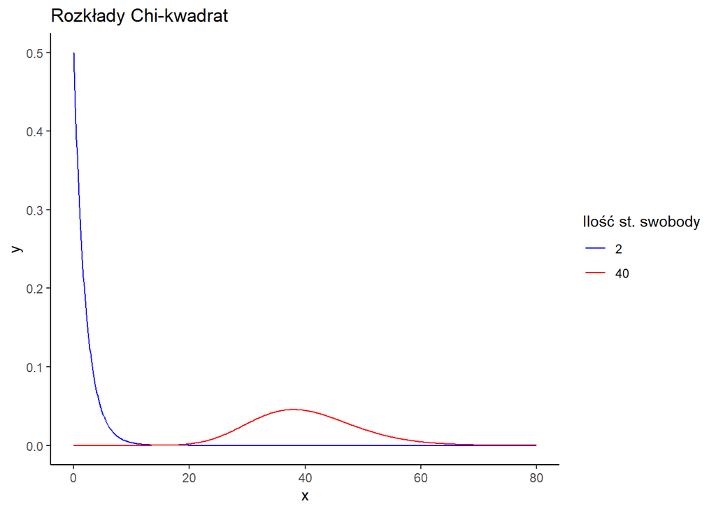

| Liczba st. swobody | EX | $\sigma$ | Skośność | Kurtoza |
| --- | --- | --- | --- | --- |
| 2 | 2 | 2 | 2 | 6 |
| 40 | 40 | 8.94 | 0.45 | 0.3 |

## Generacja danych (ad. 1, 2, 3)

W wariancie pierwszym rozkład jest generowany jako 300 średnich artmetycznych k wartości z rozkładu $\chi^{2}$, uzyskując rozkłady dokładniej przedstawione poniżej.

```r
N <- 300
k <- c(5,10,20,30,50,100,200,500,1000)
V <- c(2,40)

my_data <- data.frame(dane = NULL, k = NULL, df = NULL)

stats <- data.frame()

for( st_sw  in V ) {
  for(x in k) {

    dane <- NULL
    for (i in 1:N) {
      dane <- c(
        dane,
        mean( rchisq(x, df = st_sw) )
      )
    }
    danef <- data.frame("dane" = dane, "k" = x, "df" = st_sw)
    my_data <- rbind(my_data, danef)

  }
}
```

## Prezentacja (ad. 4, 5)

Zgodnie z *centralnym twierdzeniem granicznym*:  
Możemy zaobserwować, że wraz ze wzrostem liczby obserwacji,  
rozkład średniej arytmetycznej niezależnych zmiennych losowych o tych samych rozkładach $\chi^{2}$, wartości oczekiwanej i skończonej wariancji, dąży do postaci rozkładu normalnego.

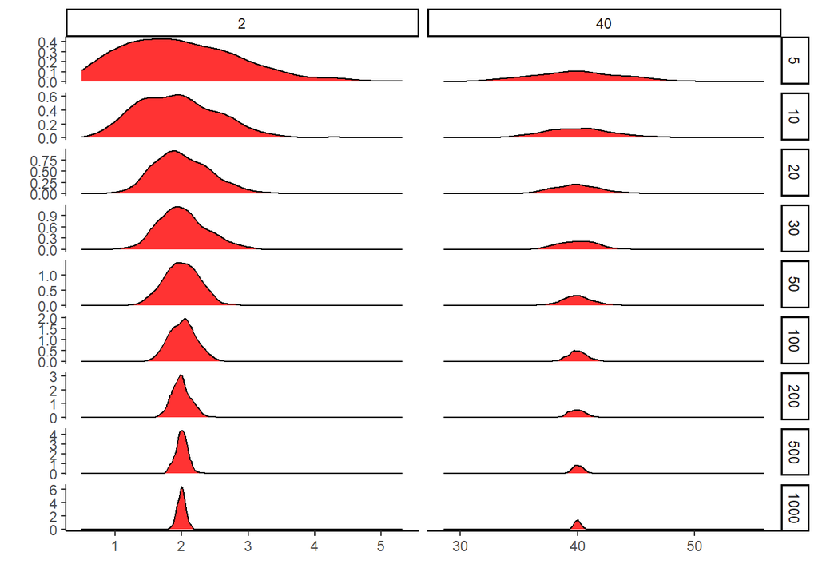

Wraz ze wzrostem liczby obserwacji, wariancja rozkładu się zmniejsza.  
Co raz więcej wartości jest skupionych wokół wartości oczekiwanej.  
Pokrywa się to postacią asymptotycznego rozkładu normalnego, do którego dąży średnia:  
$N(m, \frac{\sigma}{\sqrt(n)})$

Najbardziej widoczne jest to na wykresach pudełkowych:

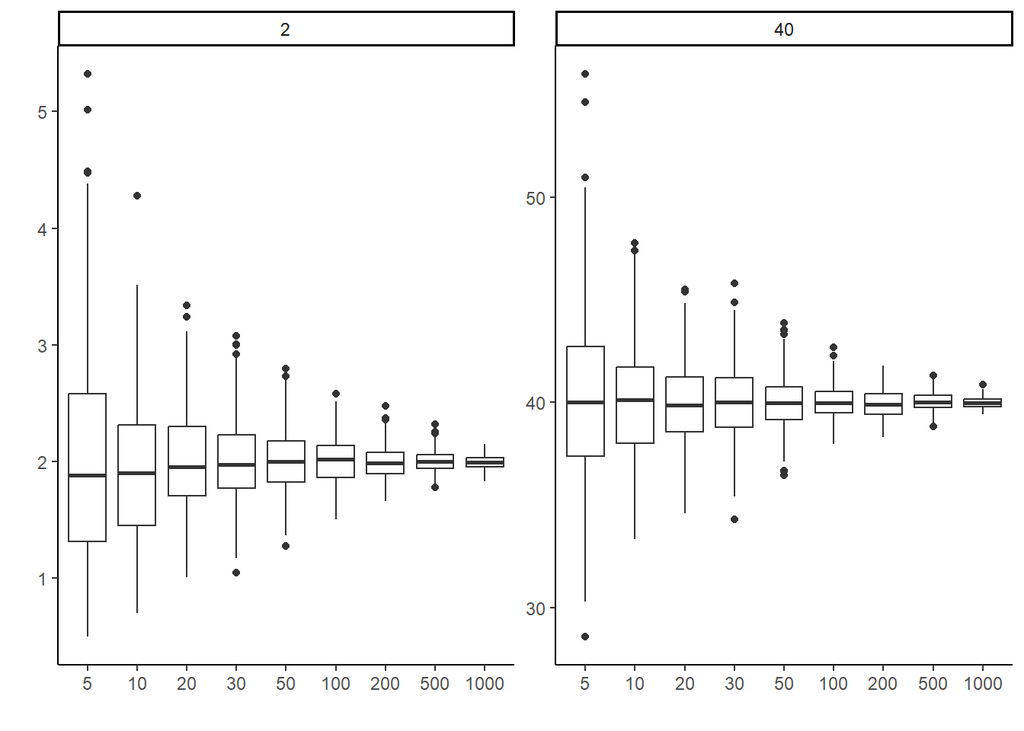

Dzięki wynikom *testu shapiro-wilka*, możemy zaobserwować jak wraz ze wzrostem danych rozkład dąży do postaci rozkładu normalnego.

```
##     df    k      p.value  Rozkład
##  1:  2    5 1.357590e-10     Inny
##  2:  2   10 2.137857e-06     Inny
##  3:  2   20 6.878076e-05     Inny
##  4:  2   30 1.687744e-02     Inny
##  5:  2   50 8.025626e-01 Normalny
##  6:  2  100 9.334631e-01 Normalny
##  7:  2  200 5.531839e-01 Normalny
##  8:  2  500 5.192447e-01 Normalny
##  9:  2 1000 5.093652e-01 Normalny
## 10: 40    5 7.049268e-01 Normalny
## 11: 40   10 2.718697e-01 Normalny
## 12: 40   20 9.623056e-02 Normalny
## 13: 40   30 3.743513e-01 Normalny
## 14: 40   50 6.473838e-01 Normalny
## 15: 40  100 9.834515e-01 Normalny
## 16: 40  200 3.693987e-01 Normalny
## 17: 40  500 7.157848e-01 Normalny
## 18: 40 1000 7.149798e-01 Normalny
```

Poniżej zostały przedstawione rozkłady dla poszczególnych liczebności próby i stopni swobody:

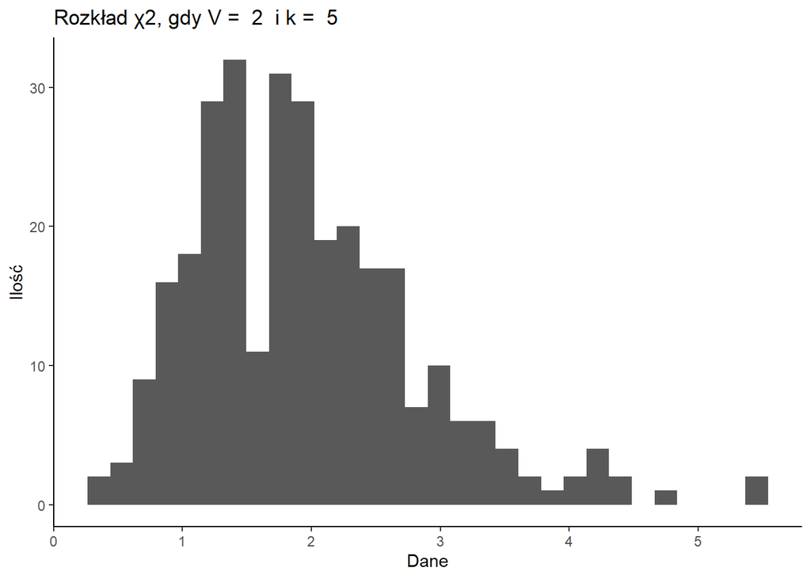

```
##  Średnia:  1.95136660695567
##  Odchylenie std:  0.875736350626554
##  Skośność:  0.986563056402563
##  Kurtoza:  4.40475692227865
```

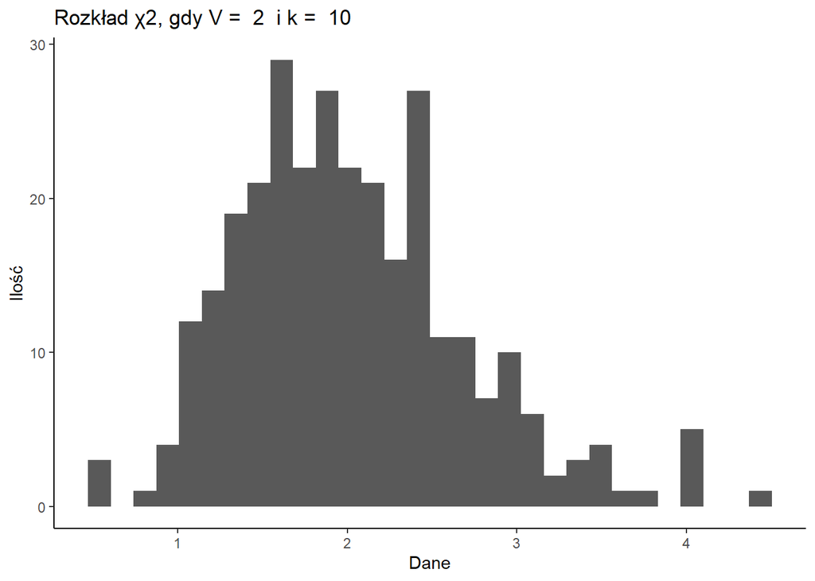

```
##  Średnia:  2.02532514579732
##  Odchylenie std:  0.677552943315782
##  Skośność:  0.702571708262389
##  Kurtoza:  3.63955824229485
```

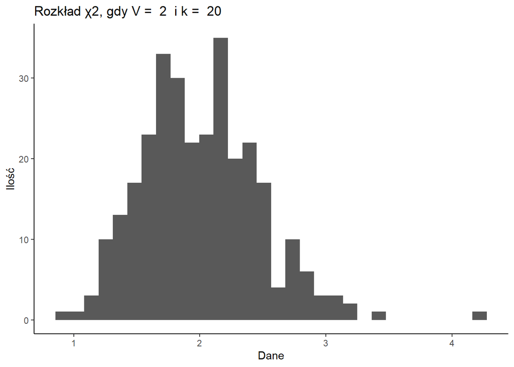

```
##  Średnia:  2.00656418966661
##  Odchylenie std:  0.465339121427611
##  Skośność:  0.66114549696179
##  Kurtoza:  4.31448286619713
```

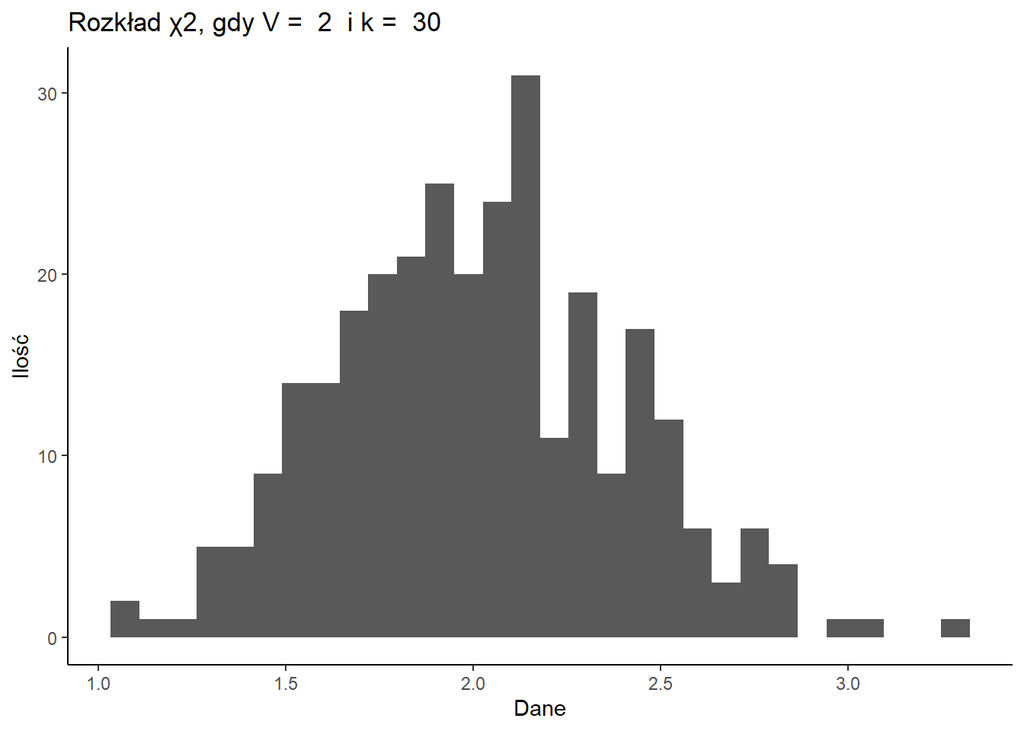

```
##  Średnia:  2.01469309472384
##  Odchylenie std:  0.379815062990995
##  Skośność:  0.21474405093185
##  Kurtoza:  2.9213094226863
```

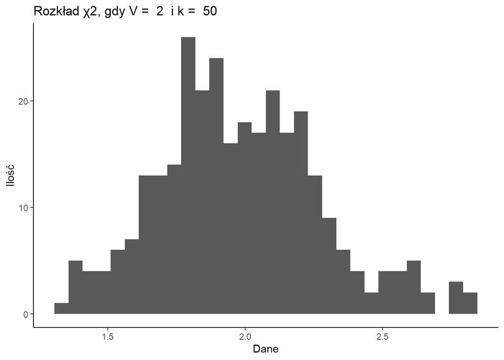

```
##  Średnia:  1.98201700660906
##  Odchylenie std:  0.294804569824178
##  Skośność:  0.364094898503831
##  Kurtoza:  3.07139615303587
```

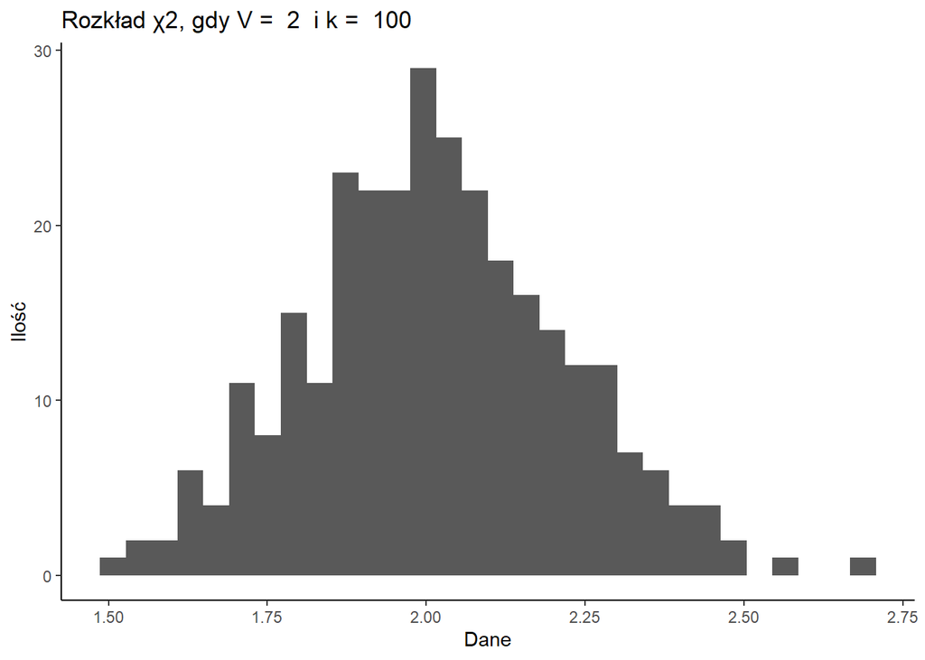

```
##  Średnia:  2.01417670490772
##  Odchylenie std:  0.202176209846909
##  Skośność:  0.195187719207613
##  Kurtoza:  2.97422818494398
```

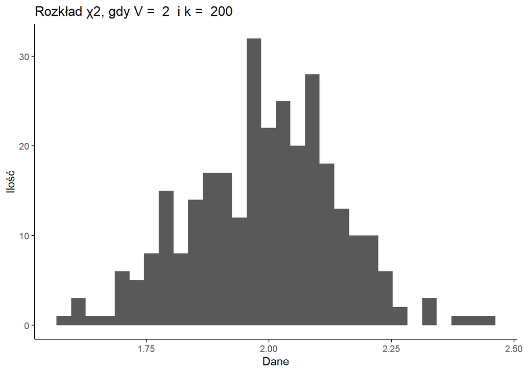

```
##  Średnia:  1.99050665804764
##  Odchylenie std:  0.150933922029147
##  Skośność:  -0.102713541088544
##  Kurtoza:  3.01672368697083
```

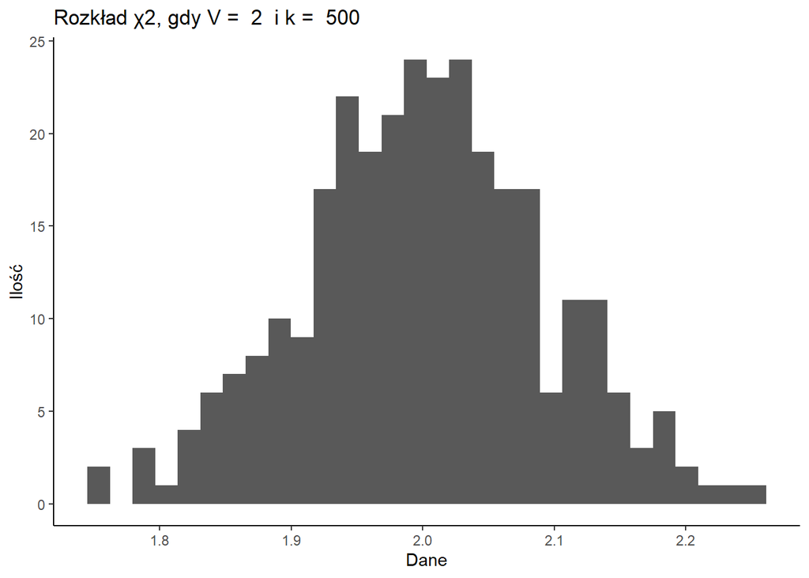

```
##  Średnia:  2.00068140156099
##  Odchylenie std:  0.0910036506138459
##  Skośność:  0.0226682477717096
##  Kurtoza:  2.87134206531121
```

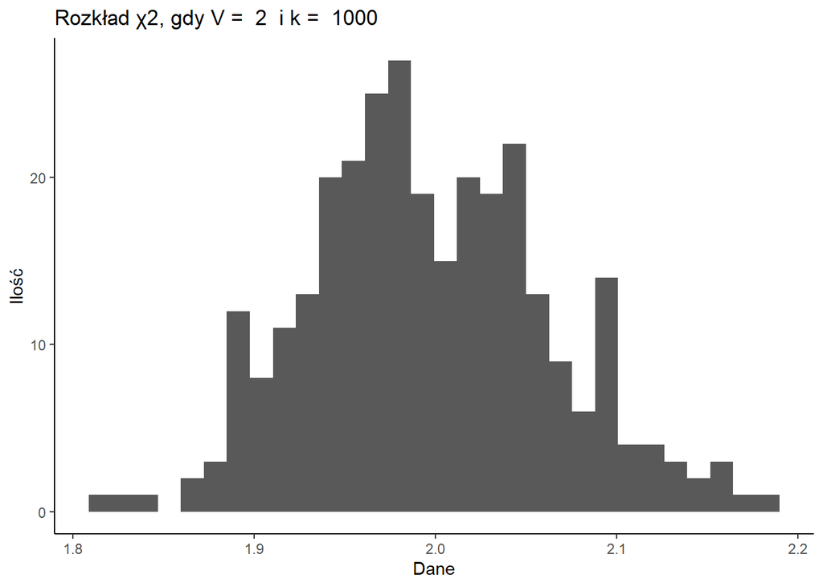

```
##  Średnia:  1.99680264565057
##  Odchylenie std:  0.0663499734499032
##  Skośność:  0.229228758079416
##  Kurtoza:  2.85667270731359
```

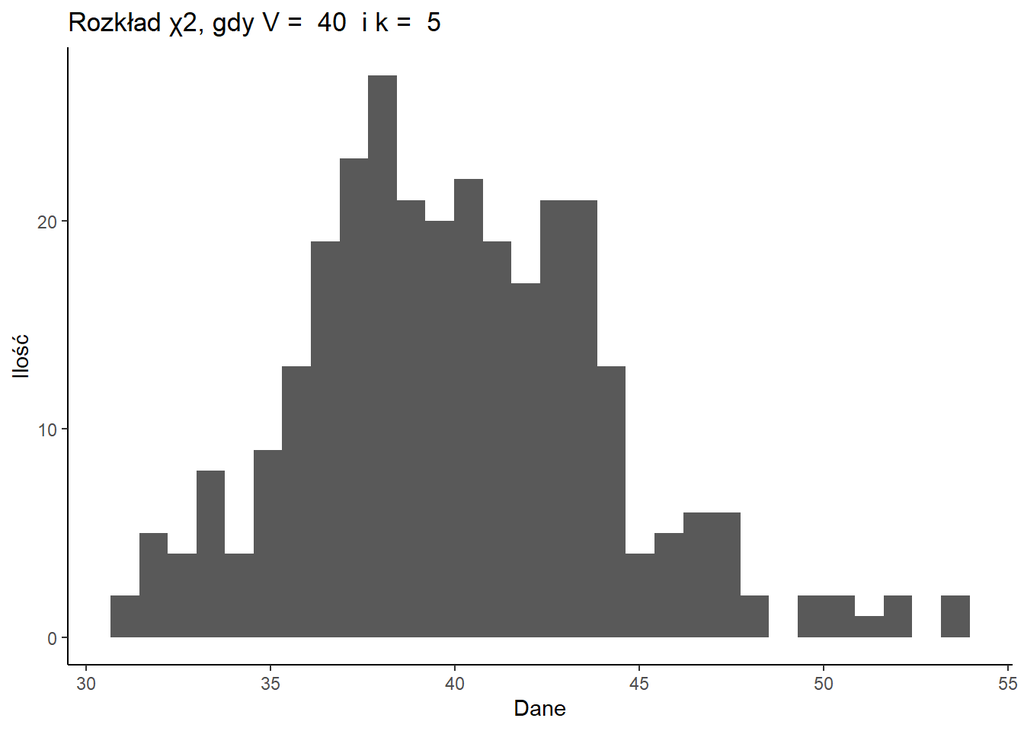

```
##  Średnia:  40.0327549050347
##  Odchylenie std:  4.11460116774734
##  Skośność:  0.44353471241869
##  Kurtoza:  3.39808941837027
```

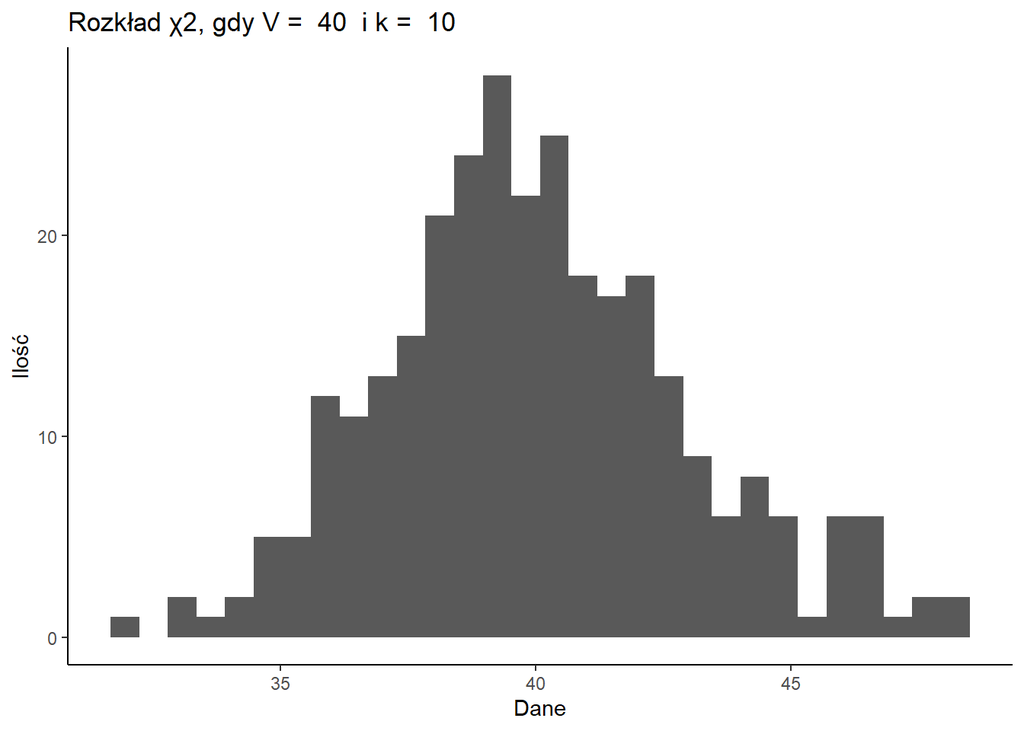

```
##  Średnia:  40.0155771785819
##  Odchylenie std:  2.9917543051087
##  Skośność:  0.304463633767359
##  Kurtoza:  3.04203888430859
```

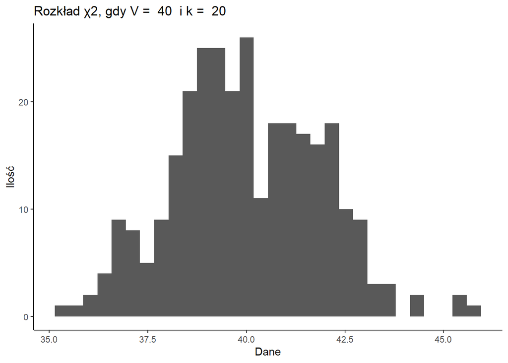

```
##  Średnia:  40.0107711161366
##  Odchylenie std:  1.86842751902131
##  Skośność:  0.138801165384131
##  Kurtoza:  2.87787407868473
```

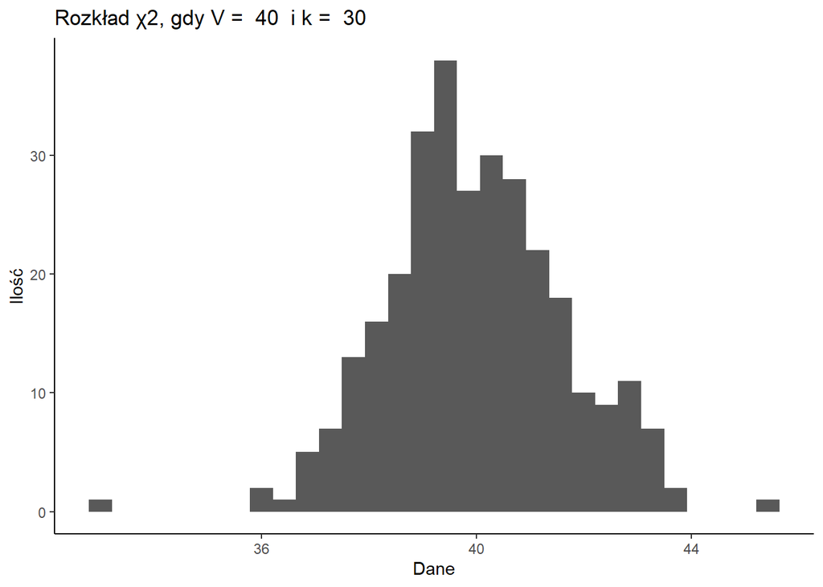

```
##  Średnia:  39.9654015578396
##  Odchylenie std:  1.62970463424675
##  Skośność:  -0.0439658095260353
##  Kurtoza:  3.81216794397664
```

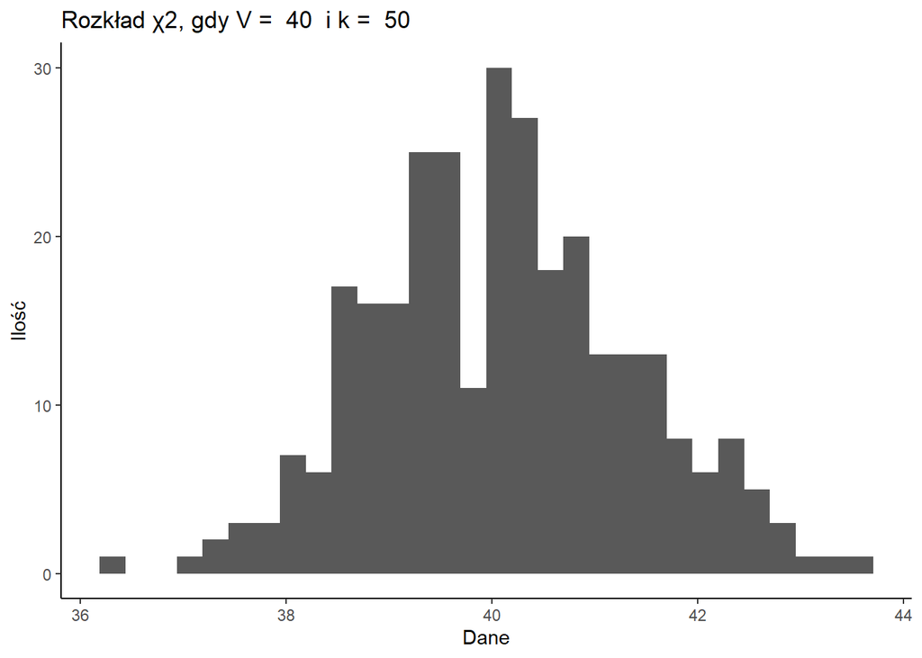

```
##  Średnia:  40.0969847443712
##  Odchylenie std:  1.25653834776587
##  Skośność:  0.1261856738151
##  Kurtoza:  2.82674073329753
```

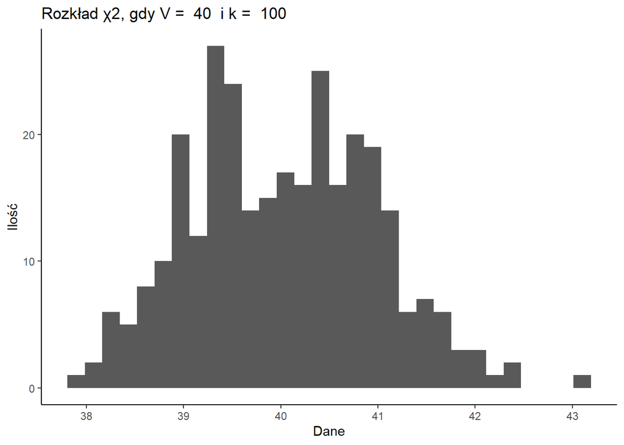

```
##  Średnia:  40.0233164592537
##  Odchylenie std:  0.945088819230299
##  Skośność:  0.188504064424492
##  Kurtoza:  2.56752519822111
```

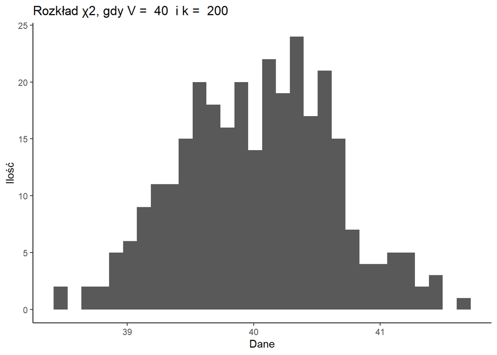

```
##  Średnia:  40.0293018535557
##  Odchylenie std:  0.605241450564702
##  Skośność:  0.017809708775881
##  Kurtoza:  2.68027993958608
```

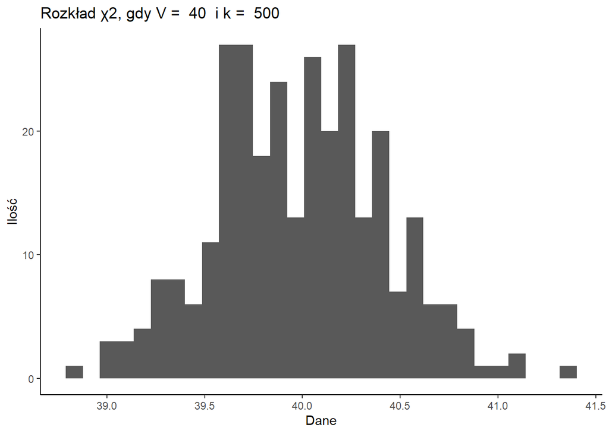

```
##  Średnia:  39.9862338035837
##  Odchylenie std:  0.431982571309609
##  Skośność:  0.11755663386864
##  Kurtoza:  2.83788701762795
```

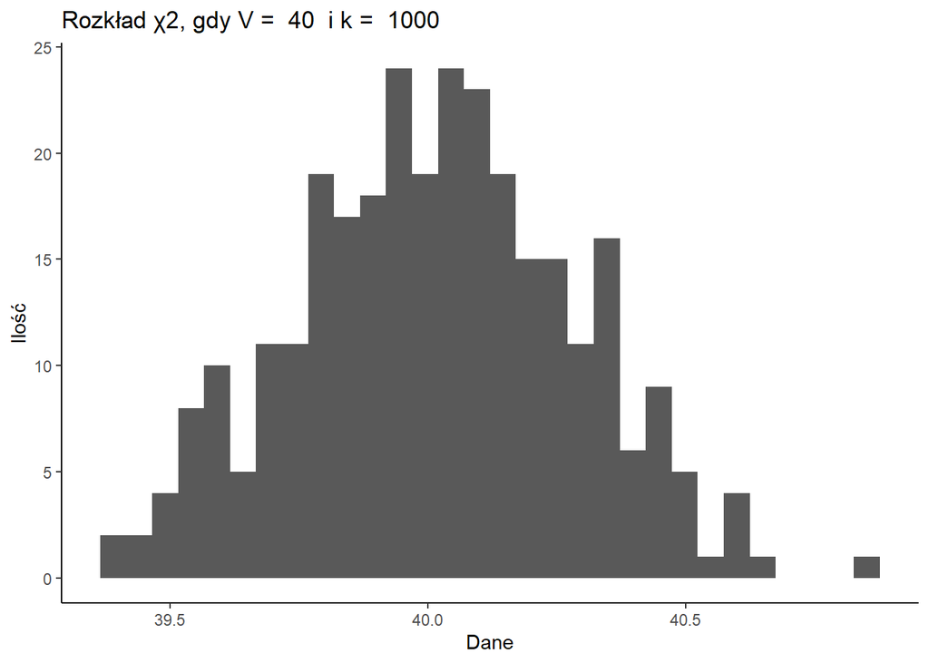

```
##  Średnia:  40.015677995207
##  Odchylenie std:  0.268368292643193
##  Skośność:  0.0601951949850568
##  Kurtoza:  2.66516638971732
```

## Podsumowanie statystyk

**Dla 2 stopni swobody:**

```
##   df    k  srednia odch_stand    skosnosc  kurtoza
## 1  2    5 1.951367 0.87573635  0.98656306 4.404757
## 2  2   10 2.025325 0.67755294  0.70257171 3.639558
## 3  2   20 2.006564 0.46533912  0.66114550 4.314483
## 4  2   30 2.014693 0.37981506  0.21474405 2.921309
## 5  2   50 1.982017 0.29480457  0.36409490 3.071396
## 6  2  100 2.014177 0.20217621  0.19518772 2.974228
## 7  2  200 1.990507 0.15093392 -0.10271354 3.016724
## 8  2  500 2.000681 0.09100365  0.02266825 2.871342
## 9  2 1000 1.996803 0.06634997  0.22922876 2.856673
```

**Dla 40 stopni swobody:**

```
##    df    k  srednia odch_stand    skosnosc  kurtoza
## 10 40    5 40.03275  4.1146012  0.44353471 3.398089
## 11 40   10 40.01558  2.9917543  0.30446363 3.042039
## 12 40   20 40.01077  1.8684275  0.13880117 2.877874
## 13 40   30 39.96540  1.6297046 -0.04396581 3.812168
## 14 40   50 40.09698  1.2565383  0.12618567 2.826741
## 15 40  100 40.02332  0.9450888  0.18850406 2.567525
## 16 40  200 40.02930  0.6052415  0.01780971 2.680280
## 17 40  500 39.98623  0.4319826  0.11755663 2.837887
## 18 40 1000 40.01568  0.2683683  0.06019519 2.665166
```

**Występując następujące zależności**:  
Przy zmianie *k*, średnia wartość pozostaje (mniej więcej) taka sama, a odchylenie standardowe stale maleje.  
Wartość kurtozy, niezależnie od liczby stopni swobody i *k* występuje w okolicach trójki.  
Dodatnia skośność przy df = 2 sugeruje, że przy małym *k* zmienna ma rozkład asymetryczny prawostronny,  
który wraz ze wzrostem *k* zmienia się coraz bardziej w rozkład symetryczny (od *k* = 50 rozkład jest już praktycznie symetryczny).  
Przy df = 40 rozkład cały czas jest symetryczny.

# Wariant II

## Teoretyczny rozkład $\chi^{2}$, którego wartości zostały podniesione do kwadratu (ad. 0)

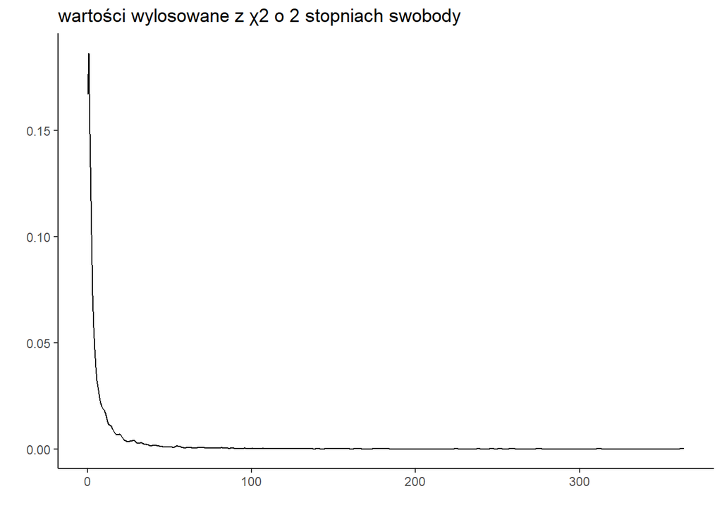

```
## Wartość oczekiwana:  8.21
```

```
## Odchylenie standardowe:  18.95
```

```
## Skośność:  6.91
```

```
## Kurtoza:  82.44
```

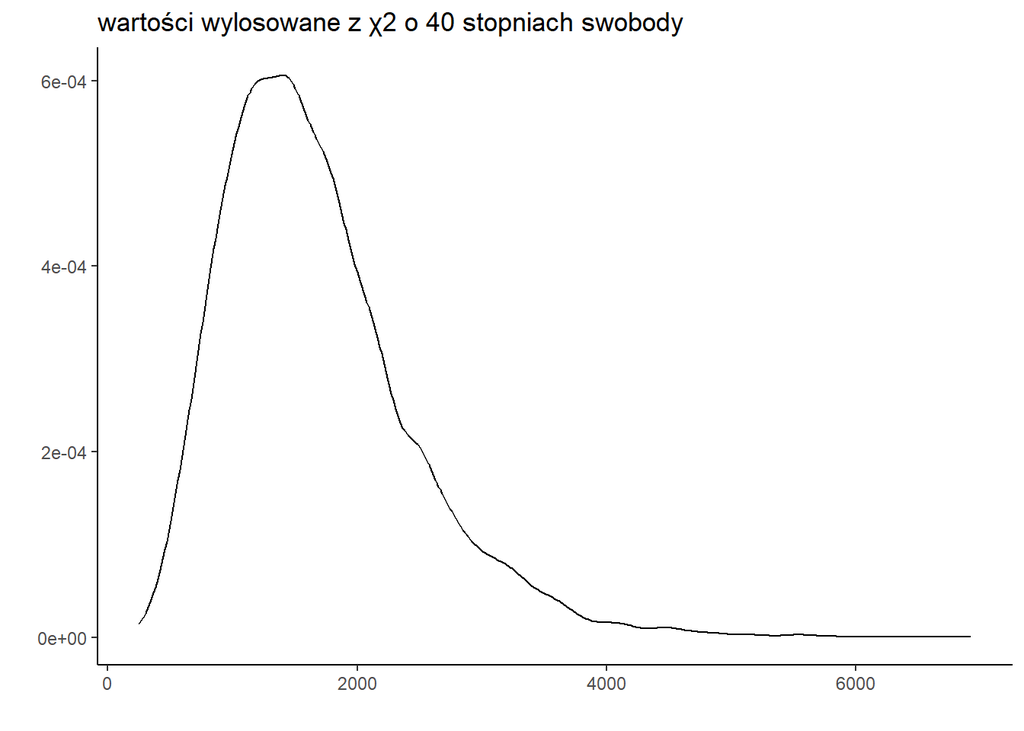

```
## Wartość oczekiwana:  1669.36
```

```
## Odchylenie standardowe:  757.49
```

```
## Skośność:  1.18
```

```
## Kurtoza:  5.38
```

## Generacja danych (ad. 1, 2, 3)

W wariancie drugim rozkład jest generowany jako 300 średnich artmetycznych k wartości z rozkładu $\chi^{2}$, podniesionych do kwadratu, uzyskując rozkłady dokładniej przedstawione poniżej.

```r
N <- 300
k <- c(5,10,20,30,50,100,200,500,1000)
V <- c(2,40)

my_data <- data.frame(dane = NULL, k = NULL, df = NULL)

for( st_sw  in V ) {
  for(x in k) {

    dane <- NULL
    for (i in 1:N) {
      dane <- c(
        dane,
        mean( rchisq(x, df = st_sw)^2 )
      )
    }
    danef <- data.frame("dane" = dane, "k" = x, "df" = st_sw)
    my_data <- rbind(my_data, danef)

  }
}
```

## Prezentacja (ad. 4, 5)

Zgodnie z wcześniej przywołanym *centralnym twierdzeniem granicznym* wraz ze wzrostem liczby obserwacji,  
rozkład średniej arytmetycznej niezależnych zmiennych losowych o tych samych rozkładach, wartości oczekiwanej i skończonej wariancji, dąży do postaci rozkładu normalnego.  
Natomiast w tym przypadku, rozkłady cechują się z początku większą asymetrią.  
Dodatkowo “prędkość” z jaką dążą do tej postaci jest mniejsza.

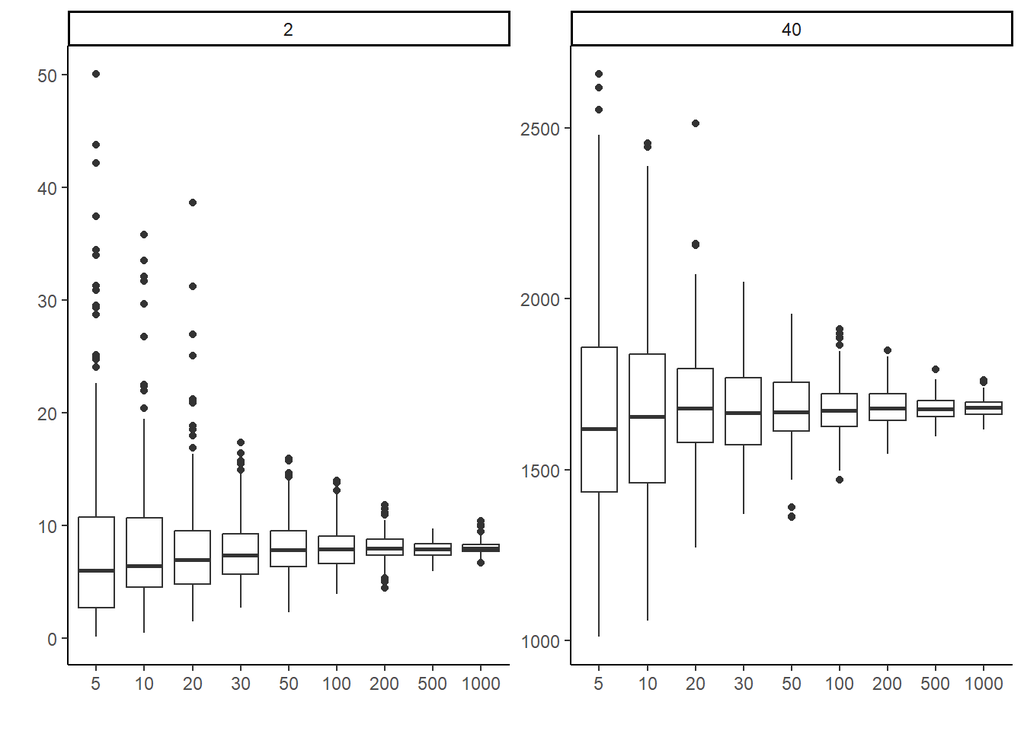

Odzwierciedlone jest to również w wynikach *testu shapiro-wilka*:

```
##     df    k      p.value  Rozkład
##  1:  2    5 1.453801e-20     Inny
##  2:  2   10 4.190549e-16     Inny
##  3:  2   20 1.470587e-12     Inny
##  4:  2   30 6.485795e-07     Inny
##  5:  2   50 4.351910e-10     Inny
##  6:  2  100 5.101100e-04     Inny
##  7:  2  200 9.462374e-02 Normalny
##  8:  2  500 2.353868e-01 Normalny
##  9:  2 1000 5.528786e-01 Normalny
## 10: 40    5 2.580012e-03     Inny
## 11: 40   10 8.192640e-05     Inny
## 12: 40   20 5.156227e-05     Inny
## 13: 40   30 7.445909e-01 Normalny
## 14: 40   50 4.261935e-01 Normalny
## 15: 40  100 2.927029e-01 Normalny
## 16: 40  200 4.904868e-01 Normalny
## 17: 40  500 6.361110e-01 Normalny
## 18: 40 1000 5.975766e-01 Normalny
```

Poniżej można zobaczyć jak prezentują się omawiane rozkłady:

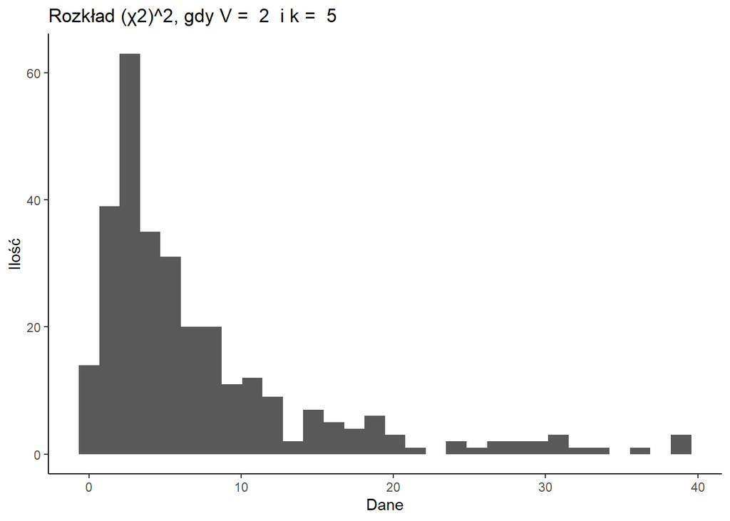

```
##  Średnia:  7.29946119518095
##  Odchylenie std:  7.63887981566454
##  Skośność:  2.0468193891059
##  Kurtoza:  7.26989871756609
```

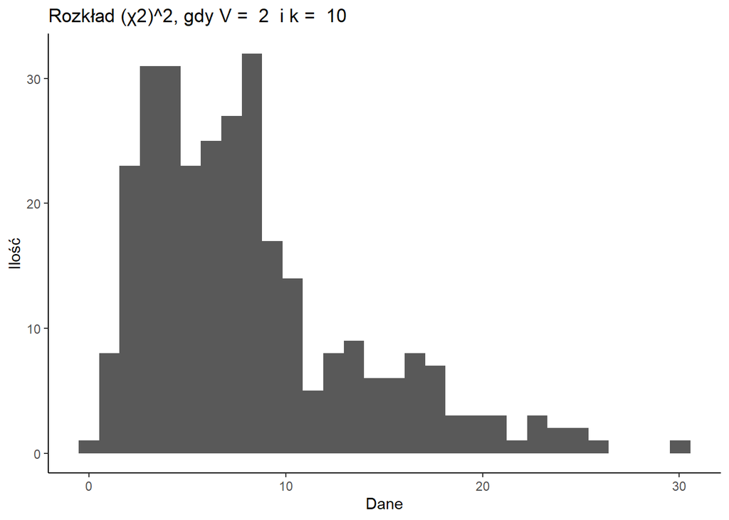

```
##  Średnia:  8.19808126840205
##  Odchylenie std:  5.50032545832686
##  Skośność:  1.23401524234649
##  Kurtoza:  4.3355484928359
```

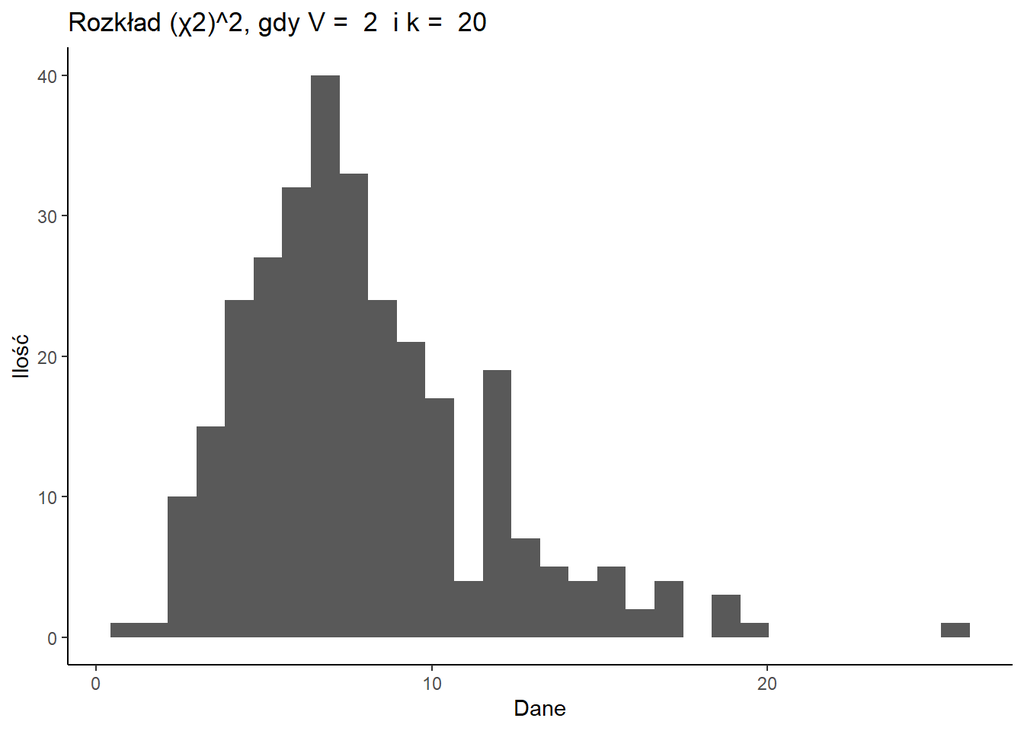

```
##  Średnia:  7.95803372158864
##  Odchylenie std:  3.63655742210794
##  Skośność:  1.15961807741956
##  Kurtoza:  5.17251988010797
```

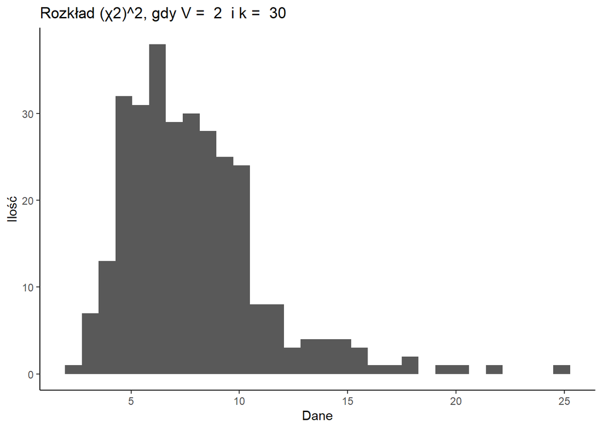

```
##  Średnia:  7.88769866537367
##  Odchylenie std:  3.27264175180163
##  Skośność:  1.55914958873764
##  Kurtoza:  6.95030319507833
```

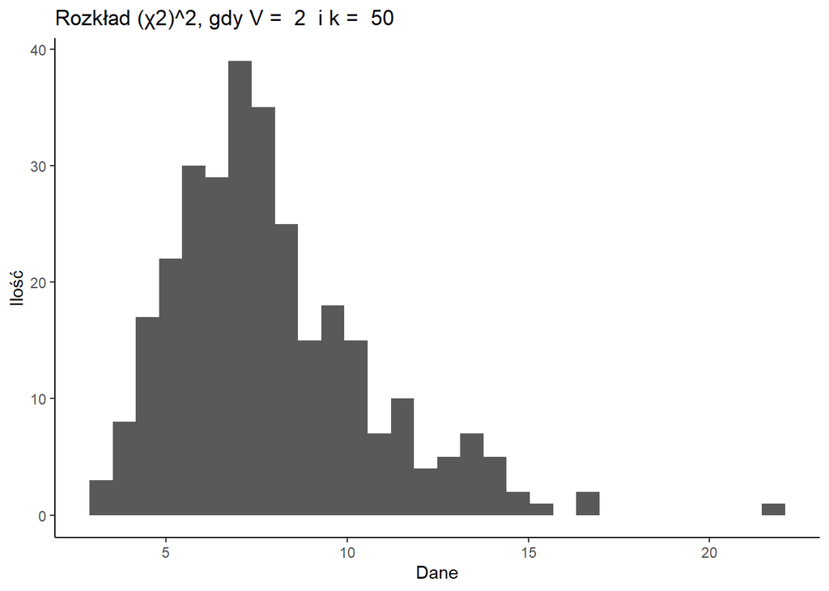

```
##  Średnia:  7.8885445074309
##  Odchylenie std:  2.70980800651012
##  Skośność:  1.12046697006119
##  Kurtoza:  5.10721811676015
```

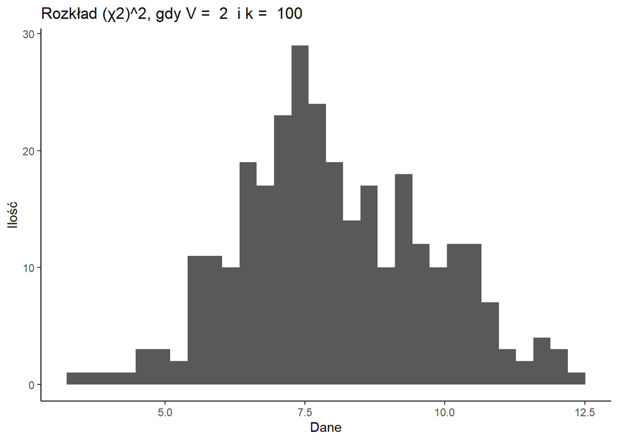

```
##  Średnia:  8.01241433401285
##  Odchylenie std:  1.70587820354899
##  Skośność:  0.184277965561944
##  Kurtoza:  2.72069625334993
```

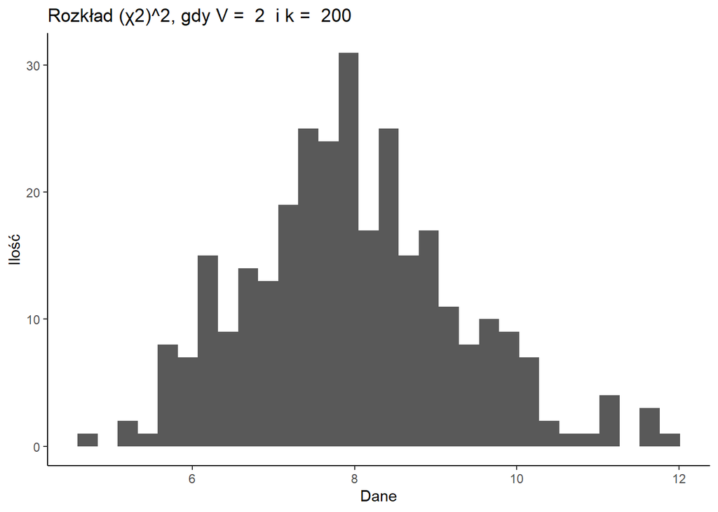